# templates_igraph

学习绘制网络

# templates_igraph

YuDalang

2016-10-10

**前提是你已经看过了igraph.pdf的前面部分**

# 第一部分

参考文档：

http://www.ituring.com.cn/article/1762

```r
# Create a directed graph
g <- make_graph(c(1,2, 1,3, 2,4, 1,4), directed=T)
g
```

```
## IGRAPH D--- 4 4 --
## + edges:
## [1] 1->2 1->3 2->4 1->4
```

```r
# Create a directed graph using adjacency matrix
m <- matrix(runif(15*15), nrow=15)
dim(m)
```

```
## [1] 15 15
```

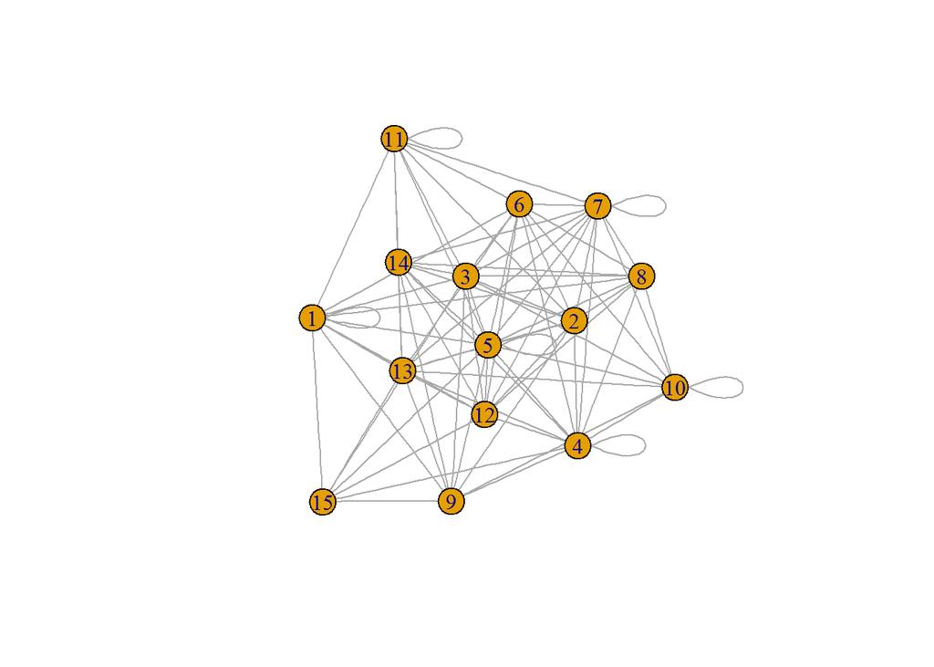

```r
g <- graph_from_adjacency_matrix(m > 0.5,mode="undirected")
plot(g, layout=layout.fruchterman.reingold)
```

```r
 #Create a full graph
g1 <- make_full_graph(5);g1
```

```
## IGRAPH U--- 5 10 -- Full graph
## + attr: name (g/c), loops (g/l)
## + edges:
##  [1] 1--2 1--3 1--4 1--5 2--3 2--4 2--5 3--4 3--5 4--5
```

```r
#Create a ring graph
g2 <- make_ring(3);g2
```

```
## IGRAPH U--- 3 3 -- Ring graph
## + attr: name (g/c), mutual (g/l), circular (g/l)
## + edges:
## [1] 1--2 2--3 1--3
```

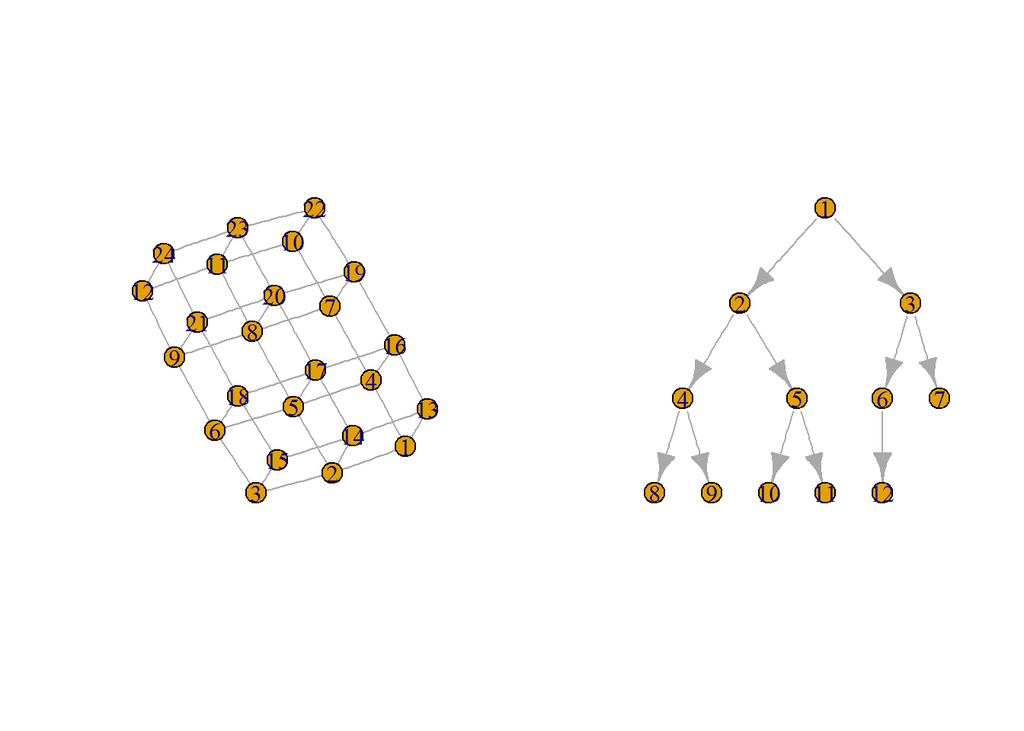

```r
#Combine 2 graphs
g <- g1 %du% g2
# Create a lattice
g1 = make_lattice(c(3,4,2))
# Create a tree
g2 = make_tree(12, children=2)
op <- par(mfrow=c(1,2))
plot(g1, layout=layout.fruchterman.reingold)
plot(g2, layout=layout.reingold.tilford)
```

iGraph还提供了另外两种图表生成的机制。“随机图表”可以在任意两个节点之间进行连线。而“优先连接”会给已经拥有较大度数的节点再增加连线（也就是多者更多）。

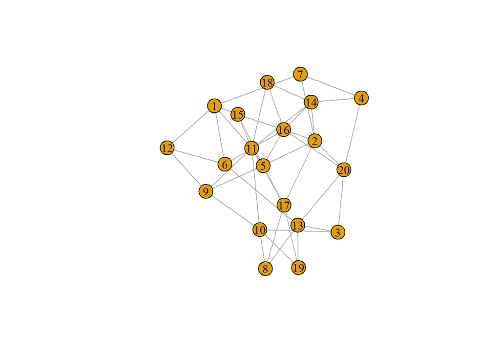

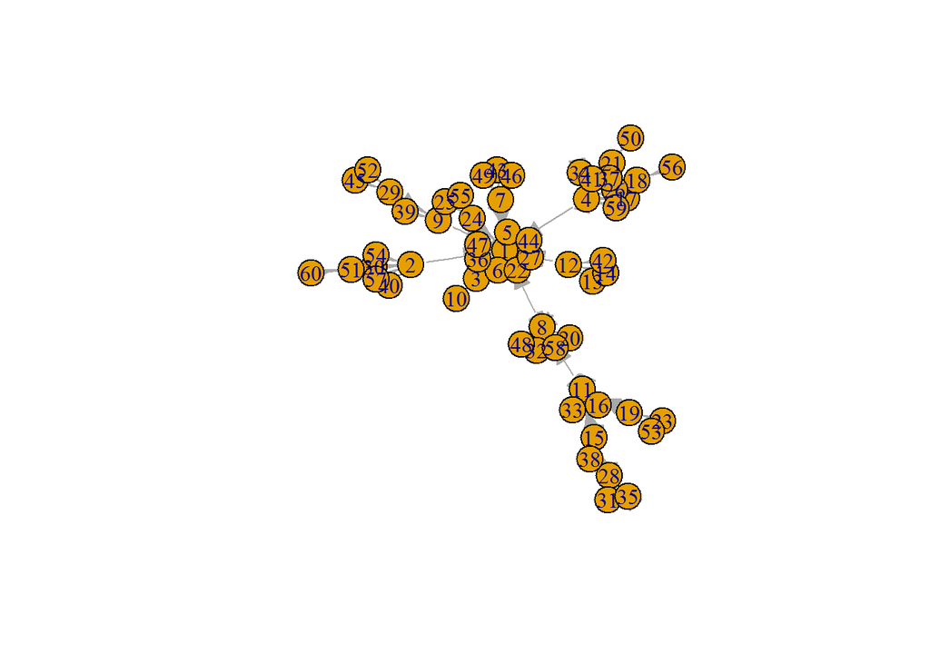

```r
# Generate random graph, fixed probability
g1 <- erdos.renyi.game(20, 0.3)
# Generate random graph, fixed number of arcs
g <- erdos.renyi.game(20, 15, type='gnm')
# Generate preferential attachment graph
g2 <- barabasi.game(60, power=1, zero.appeal=1.3)
plot(g1);plot(g2)
```

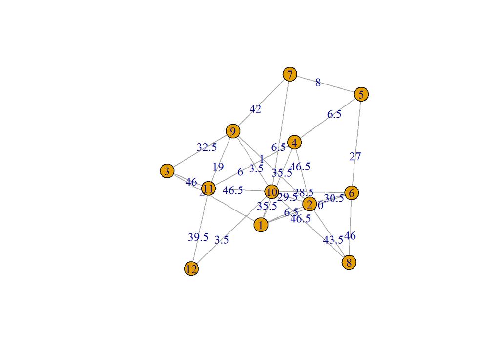

```r
par(op)
# Create the graph and assign random edge weights
g <- erdos.renyi.game(12, 0.35)
E(g)$weight <- round(runif(length(E(g))),2) * 50
plot(g, layout=layout.fruchterman.reingold, edge.label=E(g)$weight)
```

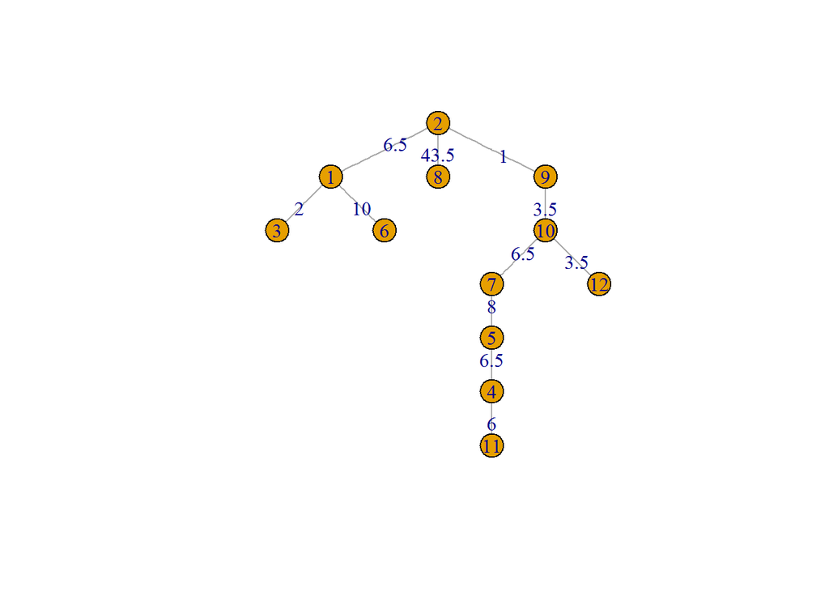

```r
# Compute the minimum spanning tree
mst <- minimum.spanning.tree(g)
plot(mst, layout=layout.reingold.tilford,  edge.label=E(mst)$weight)
```

连通分支算法可以找到会连通其他节点的连接，也就是说，两个节点之间的路径会穿过其他节点。需要注意的是，在无向图里连通是要对称的，在有向图（节点A指向节点B，但节点B不指向节点A的图表）里不是必须的。因此在有向图中存在一种连接的概念叫做“强”，也就是只有两个节点都分别指向对方才意味着它们是连通的。“弱”的连接意味着它们不是连通的。

```r
g <- make_graph(c(1, 2, 2, 3, 3, 1, 2, 4, 4, 5, 5, 6, 6, 4, 5, 7, 7, 8, 8, 9, 9, 7, 10, 11, 11, 12, 12, 10))#默认是Directer的图形
# Nodes reachable from node5
subcomponent(g, 5, mode="out")
```

```
## + 6/12 vertices:
## [1] 5 6 7 4 8 9
```

```r
# Nodes who can reach node4
subcomponent(g, 5, mode="in")
```

```
## + 6/12 vertices:
## [1] 5 4 2 6 1 3
```

```r
clusters(g, mode="weak")
```

```
## $membership
##  [1] 1 1 1 1 1 1 1 1 1 2 2 2
##
## $csize
## [1] 9 3
##
## $no
## [1] 2
```

```r
myc <- clusters(g, mode="strong");myc
```

```
## $membership
##  [1] 2 2 2 3 3 3 4 4 4 1 1 1
##
## $csize
## [1] 3 3 3 3
##
## $no
## [1] 4
```

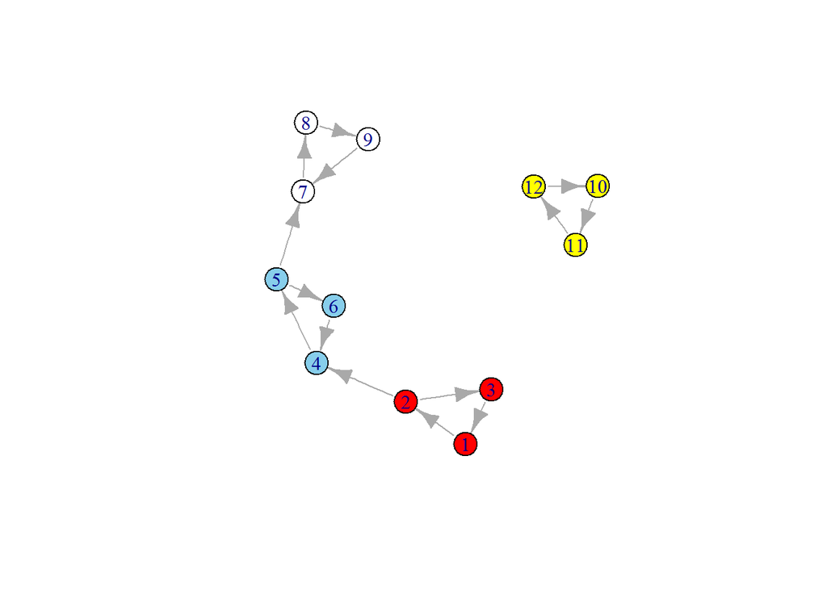

```r
mycolor <- c('green', 'yellow', 'red', 'skyblue')
V(g)$color <- mycolor[myc$membership + 1]
plot(g, layout=layout.fruchterman.reingold)
```

最短路径算法是最普遍的算法，它能找到节点A和节点B之间最短的路径。在iGraph里，如果图表是未加权的（也就是权重为1的）而且在权重为正时使用了迪杰斯特拉算法，会使用“breath-first search”算法。要是连线的权重是负数，则会使用Bellman-ford算法。

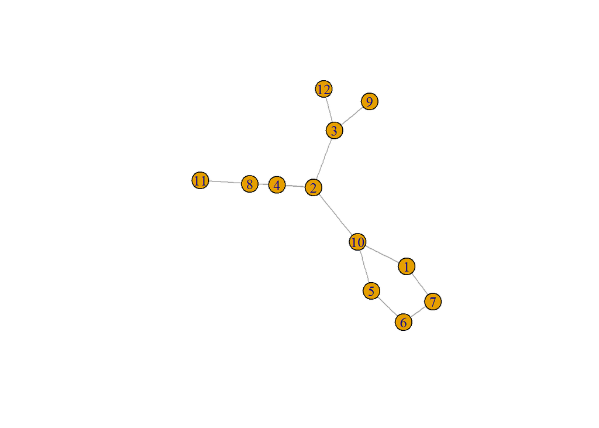

```r
set.seed(1)
g <- erdos.renyi.game(12, 0.25)
plot(g, layout=layout.fruchterman.reingold)
```

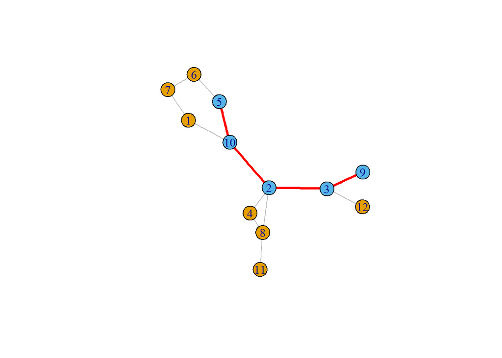

```r
pa <- shortest_paths(g, 5, 9)[[1]]
pa<-as.vector(pa[[1]])#as a vector
comps <- components(g)$membership
colbar<-comps;colbar[pa]<-colbar[pa]+1#将最短路径的颜色设置得和其它的节点的颜色不同
V(g)$color <-colbar
E(g)$color <- 'grey'
E(g, p=pa)$color <- 'red'
E(g, p=pa)$width <- 3
plot(g, layout=layout.fruchterman.reingold)
```

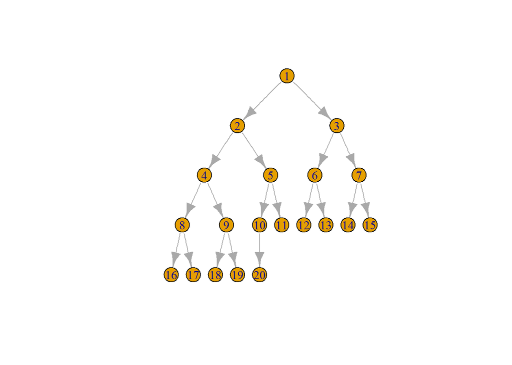

```r
#tree
t<-make_tree(20, 2)
plot(t,layout=layout_as_tree(t))
```

**图表统计**

通过大量统计信息我们可以大致看到图表的形状。在最高权限下，我们可以看到图表的各类信息，它包括:

- 图表的大小（节点和连线的数量）
- 图表的密度是紧密的（|E|与|V|的平方成正比）还是稀疏的（|E|与|V|成正比）?
- 图表是连通的（大部分节点是互通的）还是非连通的（节点是孤立的）？
- 图表中最长的两点之间距离
- 有向图的对称性
- 出/入“度”的分布

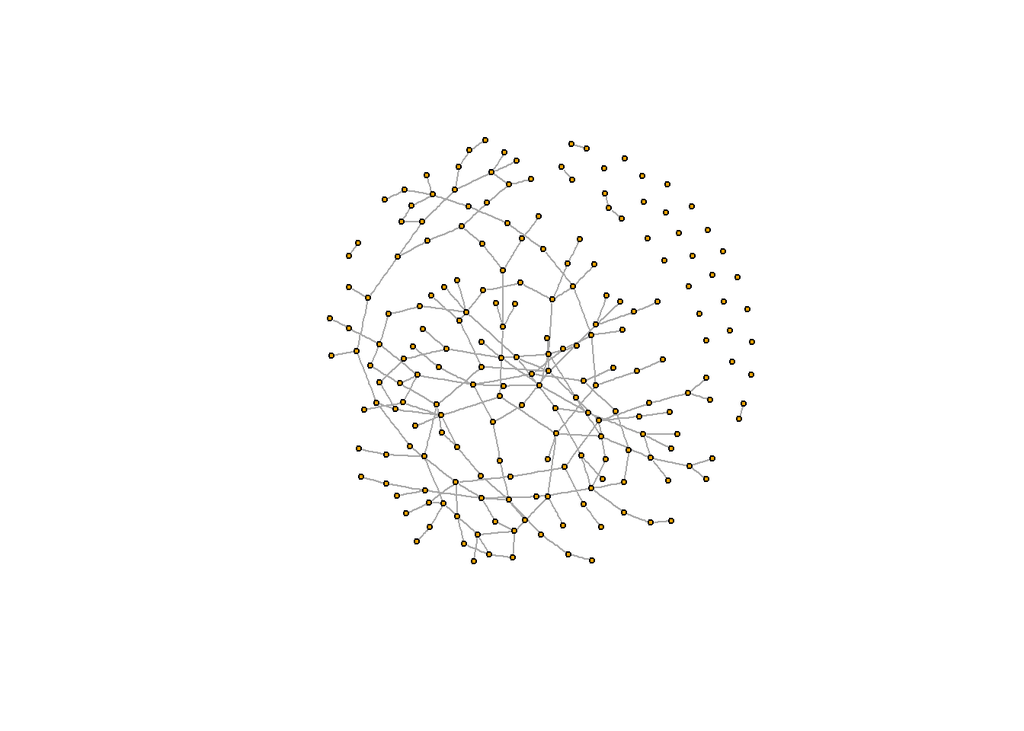

```r
# Create a random graph
g <- erdos.renyi.game(200, 0.01)
plot(g, layout=layout.fruchterman.reingold, vertex.label=NA, vertex.size=3)
```

```r
length(V(g))# No of nodes
```

```
## [1] 200
```

```r
length(E(g))# No of edges
```

```
## [1] 196
```

```r
graph.density(g)# Density (No of edges / possible edges)
```

```
## [1] 0.009849246
```

```r
clusters(g)$no# Number of islands
```

```
## [1] 30
```

```r
# Global cluster coefficient:
#(close triplets/all triplets)
transitivity(g, type="global")
```

```
## [1] 0.008152174
```

```r
# Edge connectivity, 0 since graph is disconnected
edge.connectivity(g)
```

```
## [1] 0
```

```r
graph.adhesion(g) # Same as graph adhesion
```

```
## [1] 0
```

```r
diameter(g) # Diameter of the graph
```

```
## [1] 17
```

```r
reciprocity(g) # Reciprocity of the graph
```

```
## [1] 1
```

```r
degree.distribution(g)
```

```
## [1] 0.120 0.305 0.265 0.170 0.090 0.045 0.005
```

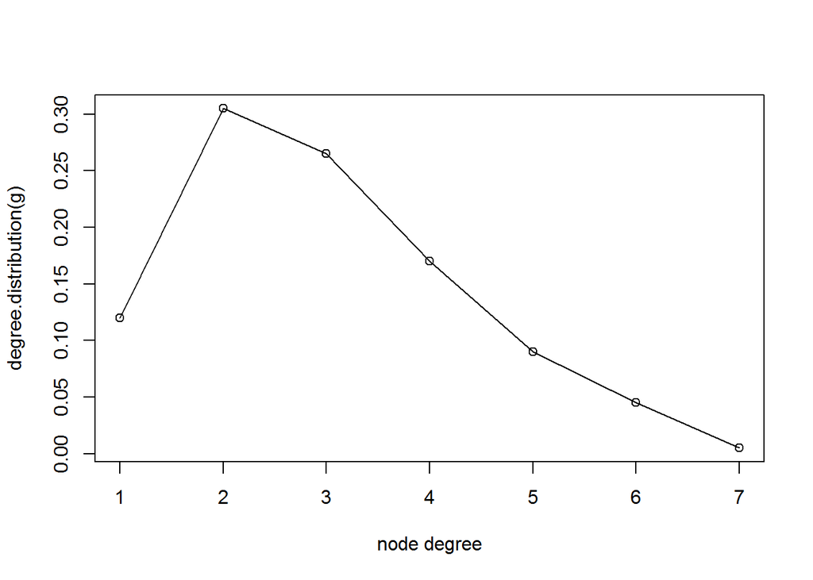

```r
plot(degree.distribution(g), xlab="node degree")
lines(degree.distribution(g))
```

**中心性计算**

在细节方面，我们可以看到各个节点的统计信息。根据这些数字可以测出节点的“中心性”

- 拥有较高出/入度数的节点也拥有较高的“度中心性”
- 与其他节点之间有短路径的节点拥有较高的“密集中心性”
- 与其他节点对之间有最短路径的节点拥有较高的“中间性”
- 连接了许多中心性较高节点的节点拥有较高的“特征向量中心性”
- 本地簇系数意味着相邻节点的互联性

```r
head(degree(g))# Degree and the max one
```

```
## [1] 1 0 2 3 2 2
```

```r
which(degree(g)==max(degree(g)))
```

```
## [1] 21
```

```r
head(closeness(g))# Closeness (inverse of average dist)
```

```
## [1] 1.220256e-04 2.512563e-05 1.234416e-04 1.232590e-04 1.254390e-04
## [6] 1.224740e-04
```

```r
head(betweenness(g))# Betweenness
```

```
## [1]   0.0000   0.0000 150.9167 379.0346 516.7389 483.0000
```

```r
head(transitivity(g, type="local")) # Local cluster coefficient
```

```
## [1] NaN NaN   0   0   0   0
```

```r
head(evcent(g)$vector)# Eigenvector centrality
```

```
## [1] 9.983425e-02 6.353410e-17 2.126613e-01 3.253066e-01 2.644718e-01
## [6] 2.681762e-01
```

从中Drew Conway发现拥有低“特征向量中心性”和高“中间性”的人是很重要的联系人，而拥有高“特征向量中心性”和低“中间性”的人与重要的人有关联。现在我们来绘制“特征向量中心性”和“中间性”的图表。

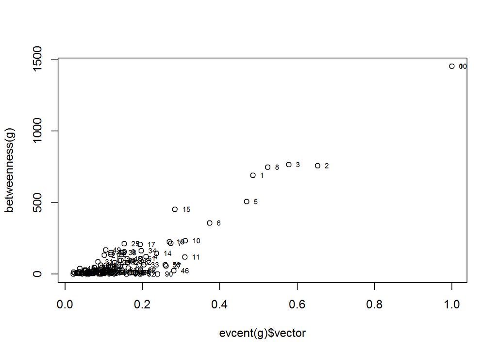

```r
 # Create a graph
g1 <- barabasi.game(100, directed=F)
g2 <- barabasi.game(100, directed=F)
g <- g1 %u% g2
lay <- layout.fruchterman.reingold(g)
# Plot the eigevector and betweenness centrality
plot(evcent(g)$vector, betweenness(g))
text(evcent(g)$vector, betweenness(g), 0:100, cex=0.6, pos=4.5)
```

## 二、igraph简明教程

```r
g <- graph( c(1,2, 1,3, 2,3, 3,5), n=5 )
#查看查看igraph的信息
summary(g); is.igraph(g);is.dag(g);is.directed(g)
```

```
## IGRAPH D--- 5 4 --
```

```
## [1] TRUE
```

```
## [1] TRUE
```

```
## [1] TRUE
```

```r
#Vertices 节点；Edges: 边 的数量
vcount(g); ecount(g)
```

```
## [1] 5
```

```
## [1] 4
```

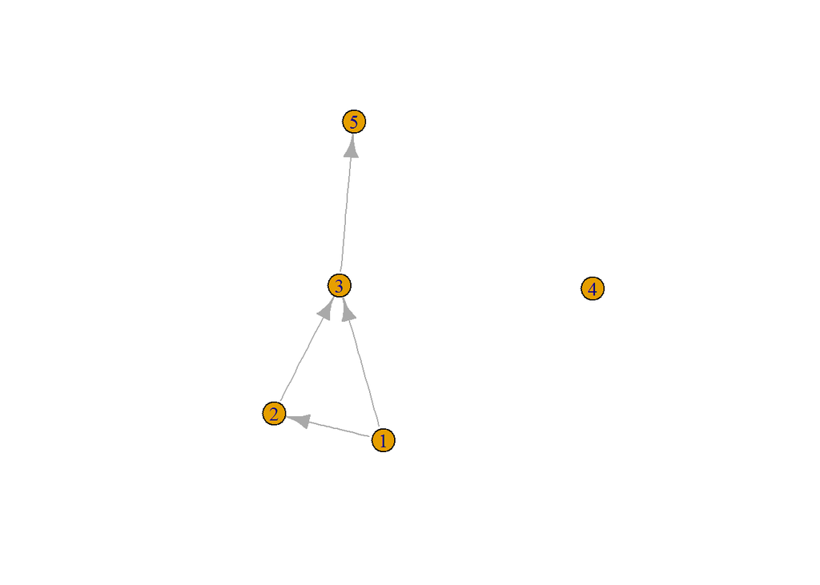

```r
# Visualization可视化
plot(g)
```

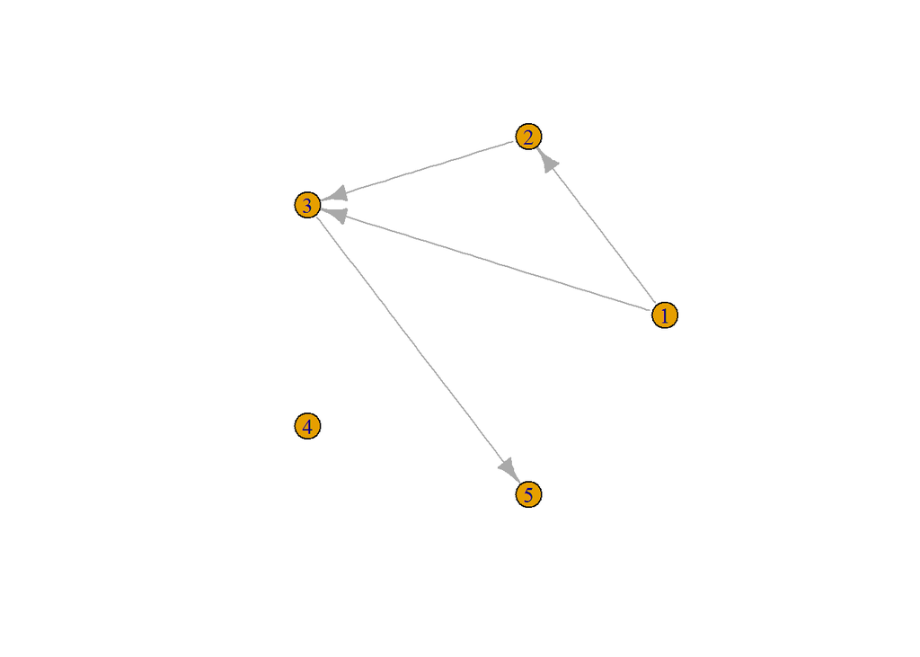

```r
plot(g, layout=layout.circle)
```

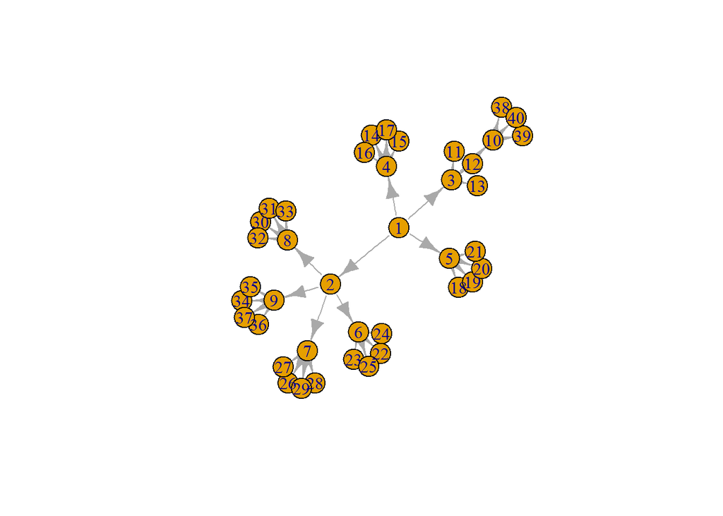

```r
#换一种igraph
g <- graph.tree(40, 4)
plot(g)
```

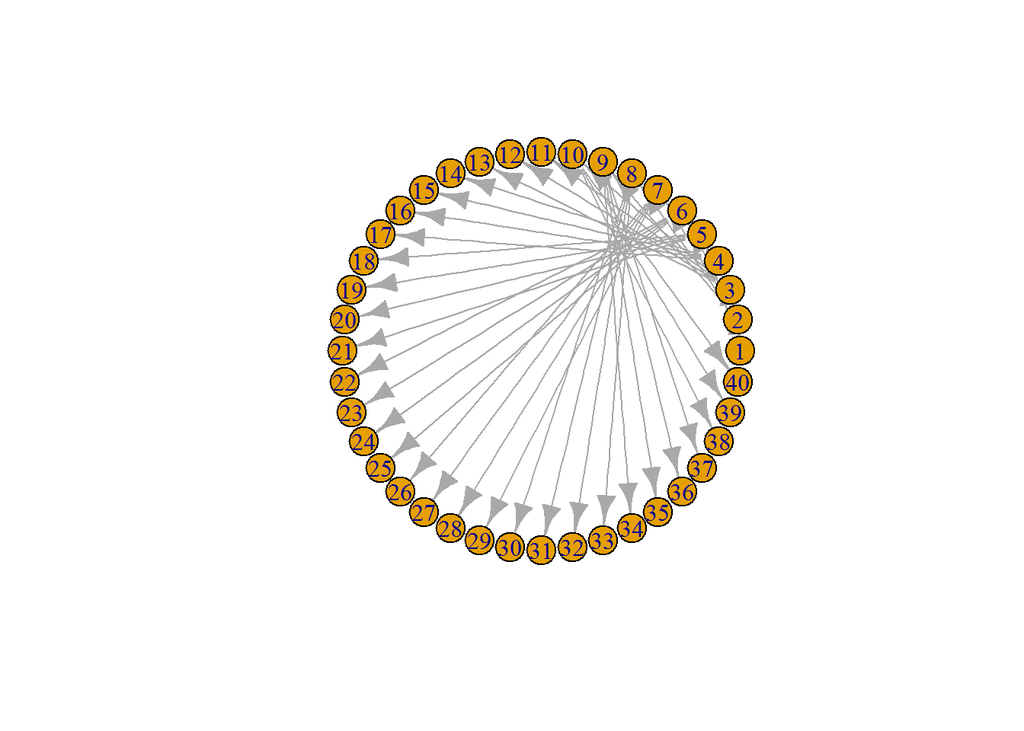

```r
plot(g, layout=layout.circle)
```

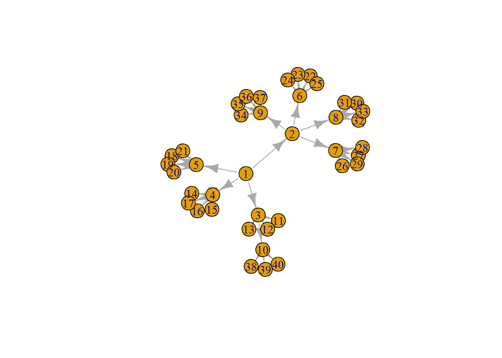

```r
#FR算法(Fruchterman-Reingold) 属于 力引导布局算法类别。
# 力引导布局（Force-directed Layout）
# 力引导布局最早由Peter Eades在1984年的“启发式画图算法”一文中提出，目的是减少布局中边的交叉，尽量保持边的长度一致。此方法借用弹簧模型模拟布局过程：用弹簧模拟两个点之间的关系，受到弹力的作用后，过近的点会被弹开而过远的点被拉近；通过不断的迭代，整个布局达到动态平衡，趋于稳定。
plot(g, layout=layout.fruchterman.reingold)
```

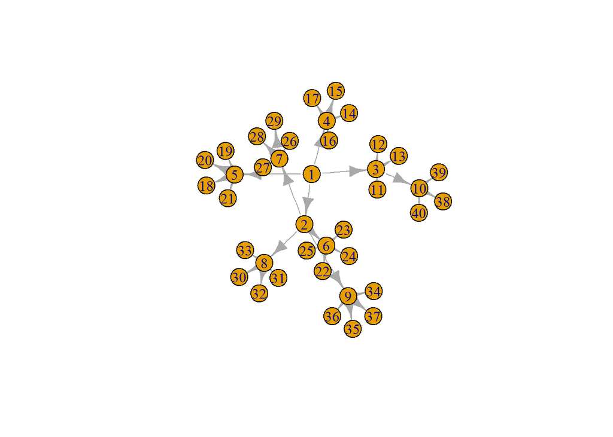

```r
plot(g, layout=layout.graphopt)
```

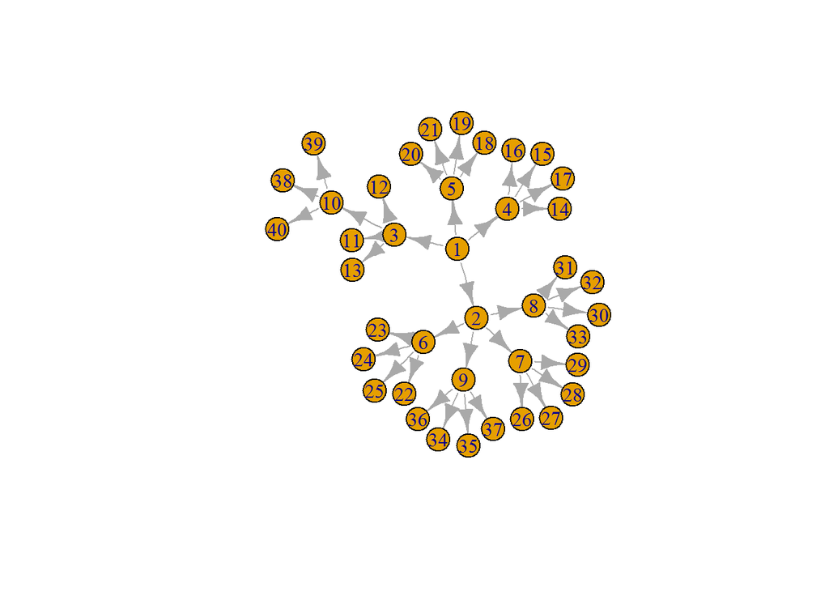

```r
plot(g, layout=layout.kamada.kawai)
```

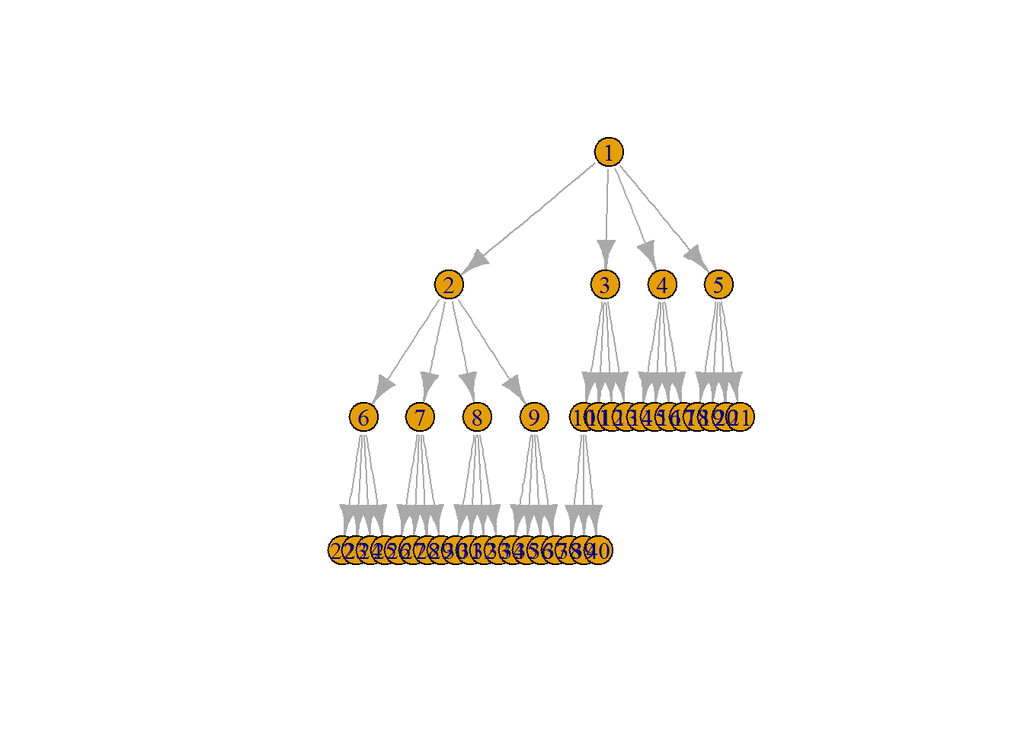

```r
plot(g, layout=layout.reingold.tilford)#画成树图
```

## 三、其它方式创建igraph

try ??graph.formula()

新版本改变了函数的名字

### Vertex/Edge sets, attributes

```r
# special operators for indexing based on graph structure
g <- sample_pa(100, power = 0.3)#Generate scale-free graphs according to the Barabasi-Albert model
E(g) [ 1:3 %--% 2:6 ]#a special operator that can be used to select all edges between two sets of vertices. It ignores the edge directions in directed graphs.#就等于intersect()取交集
E(g) [ 1:5 %->% 1:6 ]#similar to %--%, but edges from the left hand side argument, pointing to the right hand side argument, are selected, in directed graphs.
E(g) [ 1:3 %<-% 2:6 ]

# the edges along the diameter
g <- sample_pa(100, directed = FALSE)
d <- get_diameter(g)
E(g, path = d)

# select edges based on attributes
g <- sample_gnp(20, 3/20) %>%
  set_edge_attr("weight", value = rnorm(gsize(.)))
E(g)[[ weight < 0 ]]
##
g <- erdos.renyi.game(100, 1/100)#Generate random graphs according to the Erdos-Renyi model
V(g)$color <- sample( c("red", "black"),
vcount(g), rep=TRUE)
E(g)$color <- "grey"
red <- V(g)[ color == "red" ]
bl <- V(g)[ color == "black" ]
E(g)[ red %--% red ]$color <- "red"
E(g)[ bl %--% bl ]$color <- "black"
plot(g, vertex.size=5, layout=
layout.fruchterman.reingold)
```

[output not shown]

## Interactive

```r
# tkplot(g, layout=layout.kamada.kawai)
# l <- layout=layout.kamada.kawai(g)
```

## 3D

```r
# l <- layout.kamada.kawai(g)
# rglplot(g, layout=l)
```

# Visual properties

```r
# plot(g, layout=l, vertex.color="cyan")
```